# Lab 2: Residual Diagnostics

MATH 4780 / MSSC 5780 Regression Analysis

Author

Mehdi Maadooliat

**NoteCourse data**

This lab uses objects in `regression_datasets.rda`. Put the `.qmd` file and `regression_datasets.rda` in the same folder before rendering or working through the lab.

## Learning goals

Use residual plots to diagnose violations of linearity, constant variance, and normality, and recognize unusual observations.

```r
library(ggplot2)
library(dplyr)
library(broom)
```

## 1. Start with a well-behaved model

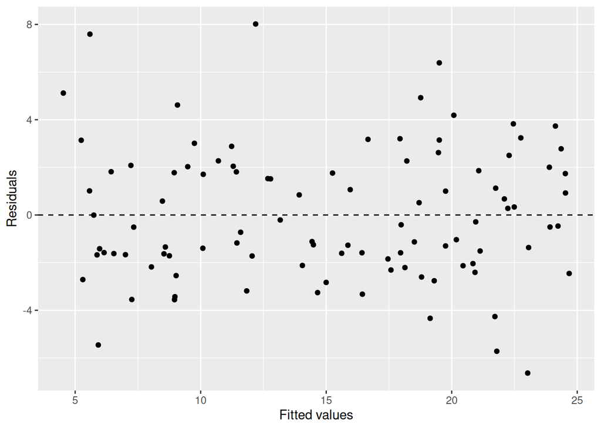

```r
set.seed(4780)

n <- 100
x <- runif(n, 0, 10)
good <- data.frame(
  x = x,
  y = 5 + 2 * x + rnorm(n, sd = 3)
)

fit_good <- lm(y ~ x, data = good)

augment(fit_good) |>
  ggplot(aes(x = .fitted, y = .resid)) +
  geom_hline(yintercept = 0, linetype = 2) +
  geom_point() +
  labs(x = "Fitted values", y = "Residuals")
```

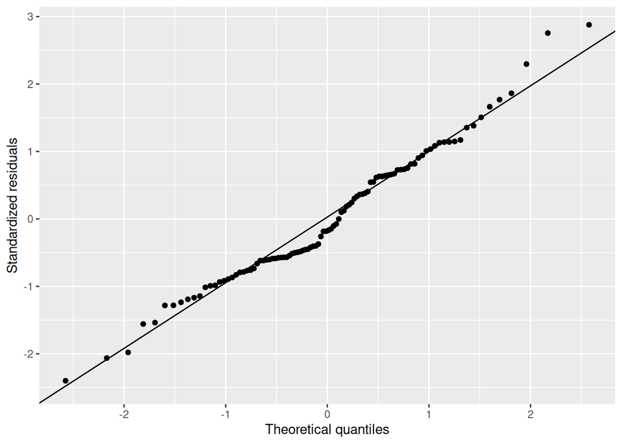

```r
augment(fit_good) |>
  ggplot(aes(sample = .std.resid)) +
  stat_qq() +
  stat_qq_line() +
  labs(x = "Theoretical quantiles", y = "Standardized residuals")
```

What features of these plots would make you comfortable with the linear model?

## 2. Nonlinearity

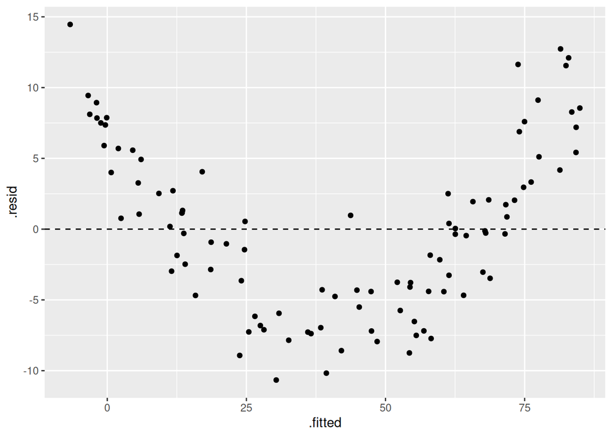

```r
nonlinear <- data.frame(
  x = x,
  y = 5 + 2 * x + 0.7 * x^2 + rnorm(n, sd = 3)
)

fit_nonlinear <- lm(y ~ x, data = nonlinear)

augment(fit_nonlinear) |>
  ggplot(aes(.fitted, .resid)) +
  geom_hline(yintercept = 0, linetype = 2) +
  geom_point()
```

What pattern indicates that the linear mean function is inadequate?

## 3. Nonconstant variance

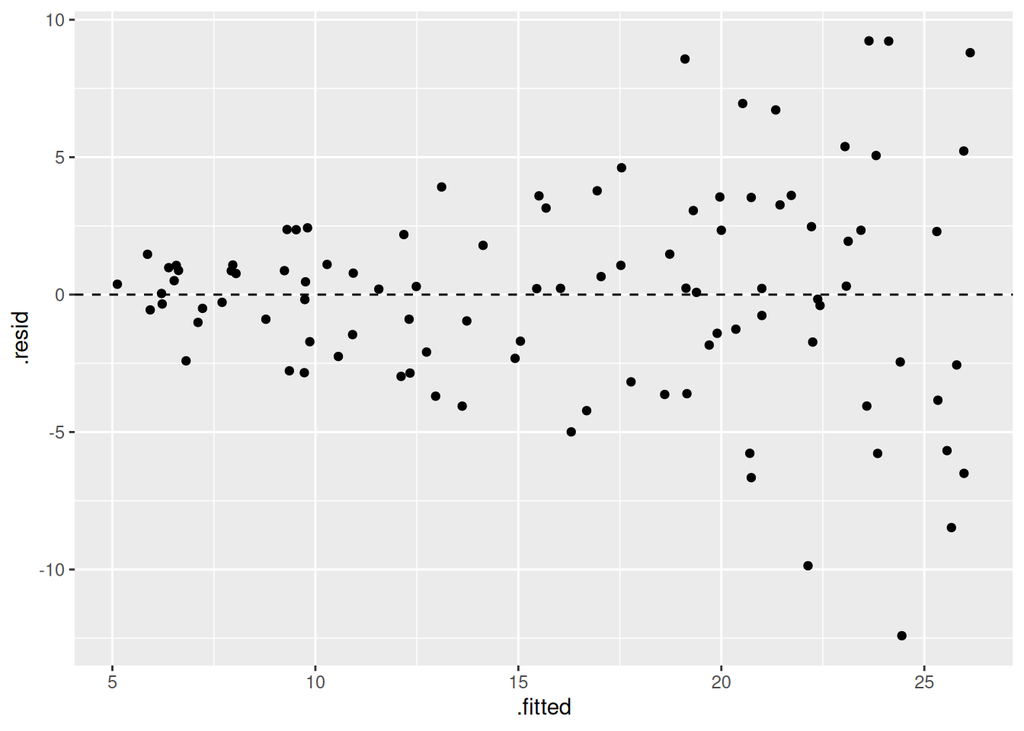

```r
hetero <- data.frame(
  x = x,
  y = 5 + 2 * x + rnorm(n, sd = 0.4 + 0.6 * x)
)

fit_hetero <- lm(y ~ x, data = hetero)

augment(fit_hetero) |>
  ggplot(aes(.fitted, .resid)) +
  geom_hline(yintercept = 0, linetype = 2) +
  geom_point()
```

Describe the change in residual spread as fitted values increase.

## 4. Nonnormal errors

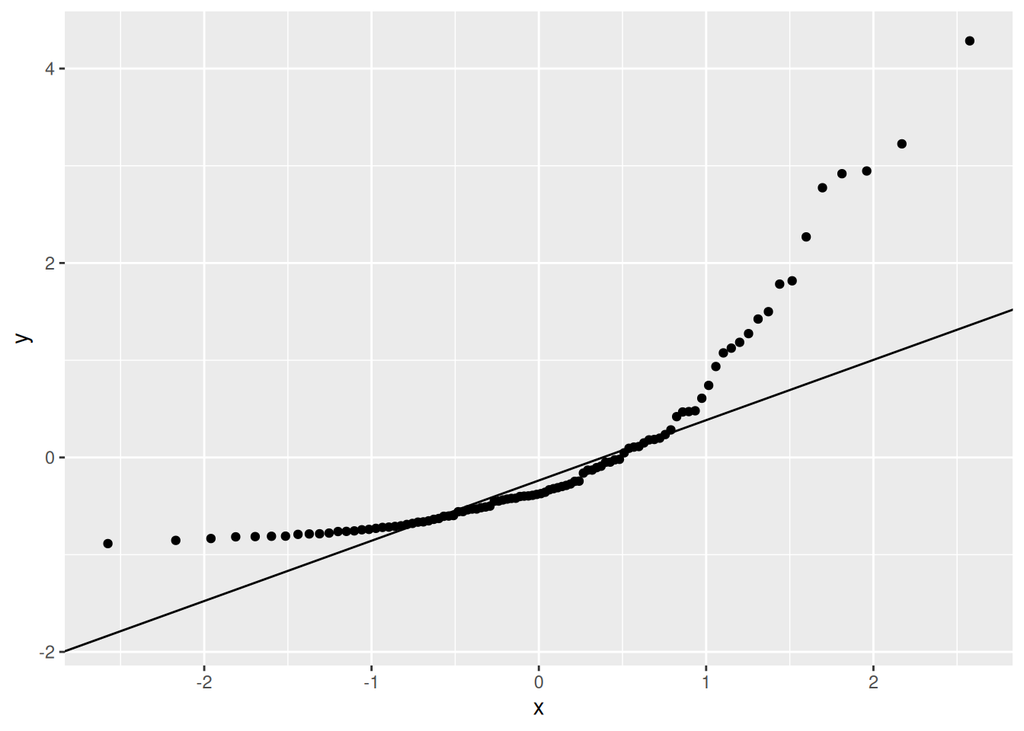

```r
nonnormal <- data.frame(
  x = x,
  y = 5 + 2 * x + (rchisq(n, df = 2) - 2)
)

fit_nonnormal <- lm(y ~ x, data = nonnormal)

augment(fit_nonnormal) |>
  ggplot(aes(sample = .std.resid)) +
  stat_qq() +
  stat_qq_line()
```

Where does the Q-Q plot depart from the reference line?

## 5. A real-data diagnostic example

The **delivery time** data are used repeatedly in the course. Fit delivery time using number of cases and distance.

```r
fit_delivery <- lm(time ~ cases + distance, data = delivery)
summary(fit_delivery)
```

```
Call:
lm(formula = time ~ cases + distance, data = delivery)

Residuals:
   Min     1Q Median     3Q    Max
-5.788 -0.663  0.436  1.157  7.420

Coefficients:
            Estimate Std. Error t value Pr(>|t|)
(Intercept)  2.34123    1.09673    2.13  0.04417 *
cases        1.61591    0.17073    9.46  3.3e-09 ***
distance     0.01438    0.00361    3.98  0.00063 ***
---
Signif. codes:  0 '***' 0.001 '**' 0.01 '*' 0.05 '.' 0.1 ' ' 1

Residual standard error: 3.26 on 22 degrees of freedom
Multiple R-squared:  0.96,  Adjusted R-squared:  0.956
F-statistic:  261 on 2 and 22 DF,  p-value: 4.69e-16
```

Use the four standard diagnostic plots:

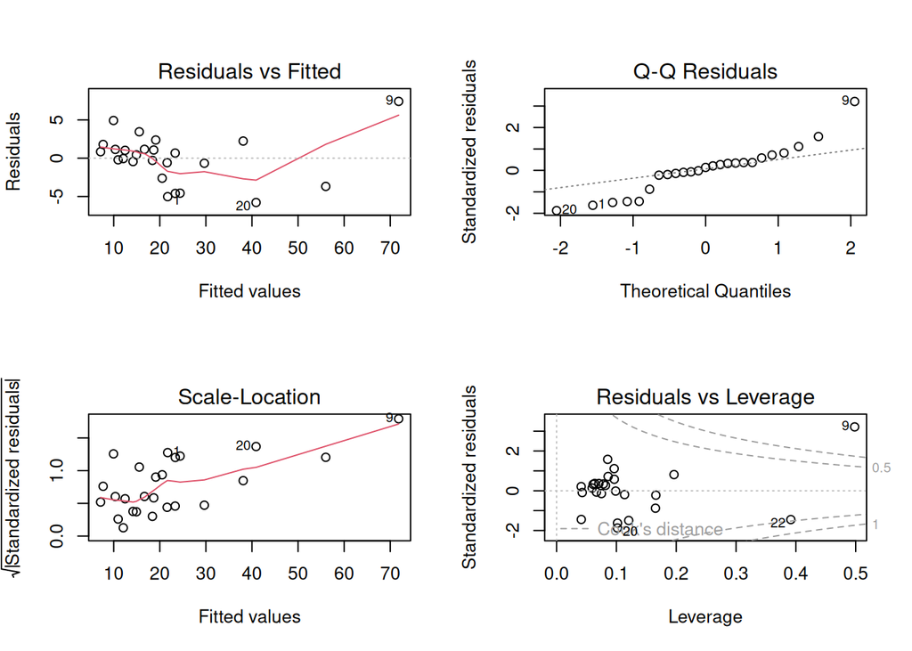

```r
par(mfrow = c(2, 2))
plot(fit_delivery)
```

```r
par(mfrow = c(1, 1))
```

Then inspect several case diagnostics directly.

```r
delivery_diag <- augment(fit_delivery) |>
  mutate(
    observation = row_number(),
    leverage = hatvalues(fit_delivery),
    cooks_d = cooks.distance(fit_delivery),
    rstudent = rstudent(fit_delivery)
  )

delivery_diag |>
  select(observation, .fitted, .resid, rstudent, leverage, cooks_d) |>
  arrange(desc(cooks_d)) |>
  head(6)
```

```
# A tibble: 6 × 6
  observation .fitted .resid rstudent leverage cooks_d
        <int>   <dbl>  <dbl>    <dbl>    <dbl>   <dbl>
1           9   71.8    7.42     4.31   0.498   3.42
2          22   56.0   -3.69    -1.49   0.392   0.451
3          20   40.9   -5.79    -2.00   0.102   0.132
4          24   24.4   -4.57    -1.54   0.121   0.102
5           1   21.7   -5.03    -1.70   0.102   0.100
6           4    9.96   4.92     1.64   0.0854  0.0776
```

1. Which assumptions appear most questionable?
2. Which observations deserve closer investigation?
3. Does an unusual observation automatically imply that it should be deleted?

## 6. Deleted residuals and PRESS

```r
press_resid <- resid(fit_delivery) / (1 - hatvalues(fit_delivery))
PRESS <- sum(press_resid^2)
PRESS
```

```
[1] 459
```

Why are deleted residuals generally larger in magnitude than ordinary residuals? How does PRESS connect residual diagnostics with prediction?

## 7. Leverage and influence are different ideas

A point can have an unusual predictor value (high leverage) without having a large residual, and a large residual does not necessarily imply high leverage. Influence combines these features by asking how much the fitted model changes.

```r
n <- nrow(delivery)
p_coef <- length(coef(fit_delivery))

delivery_diag |>
  mutate(
    high_leverage = leverage > 2 * p_coef / n,
    large_studentized = abs(rstudent) > 2
  ) |>
  select(observation, rstudent, leverage, cooks_d,
         high_leverage, large_studentized) |>
  arrange(desc(cooks_d))
```

```
# A tibble: 25 × 6
   observation rstudent leverage cooks_d high_leverage large_studentized
         <int>    <dbl>    <dbl>   <dbl> <lgl>         <lgl>
 1           9    4.31    0.498   3.42   TRUE          TRUE
 2          22   -1.49    0.392   0.451  TRUE          FALSE
 3          20   -2.00    0.102   0.132  FALSE         FALSE
 4          24   -1.54    0.121   0.102  FALSE         FALSE
 5           1   -1.70    0.102   0.100  FALSE         FALSE
 6           4    1.64    0.0854  0.0776 FALSE         FALSE
 7          10    0.807   0.196   0.0538 FALSE         FALSE
 8          21   -0.873   0.165   0.0509 FALSE         FALSE
 9          18    1.12    0.0963  0.0440 FALSE         FALSE
10          23   -1.48    0.0413  0.0299 FALSE         FALSE
# ℹ 15 more rows
```

Identify an observation that is unusual mainly because of leverage and one that is unusual mainly because of its residual, if such observations exist. Which observations are most influential according to Cook’s distance?

**TipA modeling principle**

Diagnostics identify observations that deserve investigation. They do **not** provide an automatic rule for deleting data. First check data quality, scientific context, and sensitivity of conclusions.